# apresentação

<img src = "./img/logo.jpg" align = "center">

## Atendimento 2017 - Escritório Atrium

Esta apresentação foi criada por **Erick Brunno Marinho dos Santos**. Aqui fiz um breve comentário sobre a importância do datascience para o negócios e realizei algumas análises sobre os dados dos atendimentos realizados no ano de 2017 no escritório Atrium..

<img src = './img/pandacpu.gif'>

**"Você tem todos os dados de sua empresa estruturados a ponto de tomar uma decisão estratégica olhando apenas para uma única tela?"**

<img src = "./img/bi1.jpg">

<img src = "./img/bi2.jpg">

## Tomada de Decisão

- 1 em cada 3 gestores tomam decisão com base em informações que não confiam ou não tem.
- 56% sentem sobrecarregados com a quantidade de dados que gerenciam.
- 60% acreditam que precisam melhorar captura e entender informações rapidamente.
- 83% apontam que BI & analytics fazem parte de seus planos para aumentar a competitividade.

  *fonte : Survey KPMG.*

<img src = "./img/giphy.gif">

<img src = "./img/teste.png" width = "400" height = "400">

Foi feito inicialmente, toda limpeza e tratamento dos dados. As informações encontravam-se em planilhas distintas com padrões diferentes. Termos Ambíguos, falta de preenchimento de informações, dados incorretos e várias, eu gritooooooo!!!!!!!! várias informações desordenadas.

<img src = './img/amb1.png'>

<img src = './img/amb2.png'>

**Ressalto sobre a importância de um correto preenchimento das informações no momento do atendimento, o papel fundamental da recepção no atendimento ao cliente, cito as 05 melhores práticas de bom atendimento ao cliente.**

- Entenda seu cliente: Pratique a empatia
- Comunique-se adequadamente
- Aplique a comunicação S.C.O.T (Segurança, Clareza, Objetividade e Transparência)
- Insista em ajudar Cliente a ter Sucesso (Equipe pró-ativa)
- Antecipe-se (Evita reclamações)

<img src = './img/wow.gif'>

## Perguntas a serem respondidas

Dentre outros insights gerados , quero responder as seguintes perguntas:

- Qual a área com a maior demanda?
- Quais foram os meses com maior fluxo?
- Quais os meios de indicação com maior viabilidade?
- Qual o tempo médio de formatação dos procedimentos administrativos?
- Quais são os maiores motivos de pendência?
- Ranking de atendimentos por colaboradores ?

```python
# importação das bibliotacas necessárias para o trabalho
%matplotlib inline
import pandas as pd
import matplotlib.pyplot as plt
import seaborn as sns
import random
plt.style.use('ggplot')
```

```python
#Lendo e conferindo meu dataframe
df_17 = pd.read_csv('df_concat_2017.csv')
df_17.head(1)
```

|  | mes | status_inicial | nome | atendente | area | indicacao | status_final | mes_final | tmf | pendencias | observacao_da_conclusao | contagem |
| --- | --- | --- | --- | --- | --- | --- | --- | --- | --- | --- | --- | --- |
| 0 | JANEIRO | Sem informa????es | FERNANDO LEITE TEIXEIRA FILHO | RECEPÇÃO | CÍVIL | NÃO HOUVE INDICAÇÃO | APENAS ATENDIMENTO | Sem informa????es | Sem informa????es | SEM INFORMAÇÕES | ANDAMENTO | 1 |

```python
#Cores para serem usadas nos gráficos
colors = [['#0D47A1','#1565C0','#1976D2','#1E88E5','#2196F3'],
          ['#311B92','#512DA8','#673AB7','#9575CD','#B39DDB'],
          ['#1B5E20','#388E3C','#4CAF50','#81C784','#66BB6A'],
          ['#E65100','#EF6C00','#F57C00','#FB8C00','#FF9800'],
          ['#3E2723','#4E342E','#5D4037','#6D4C41','#795548'],
          ['#BF360C','#D84315','#E64A19','#F4511E','#FF5722'],
          ['#880E4F','#AD1457','#C2185B','#D81B60','#E91E63']
         ]
```

## Qual a área com maior demanda?

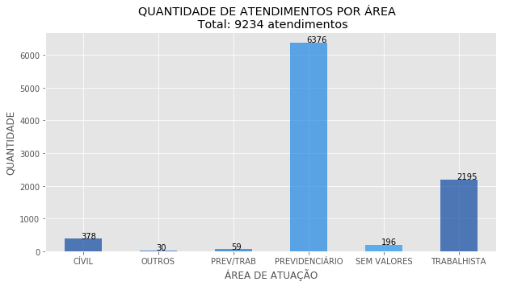

```python
demanda = df_17.groupby('area')['contagem'].sum().plot(kind = 'bar', figsize = (10,5), color = random.choice(colors), alpha = .7)

for p in demanda.patches:
    b=p.get_bbox()
    demanda.annotate("{:.0f}".format(b.y1 + b.y0), ((b.x0 + b.x1) / 2 - 0.03, b.y1 + 15))

plt.xticks(rotation=0)
plt.xlabel('ÁREA DE ATUAÇÃO')
plt.ylabel('QUANTIDADE')
plt.title('QUANTIDADE DE ATENDIMENTOS POR ÁREA  \n Total: ' + str(df_17['contagem'].sum()) + ' atendimentos')
plt.show()
```

*Como podemos ver no gráfico, a maior demanda no atendimento está relacionada a área Previdenciária, que representa 69,04% do atendimento.*

## Quais foram os meses com maior fluxo?

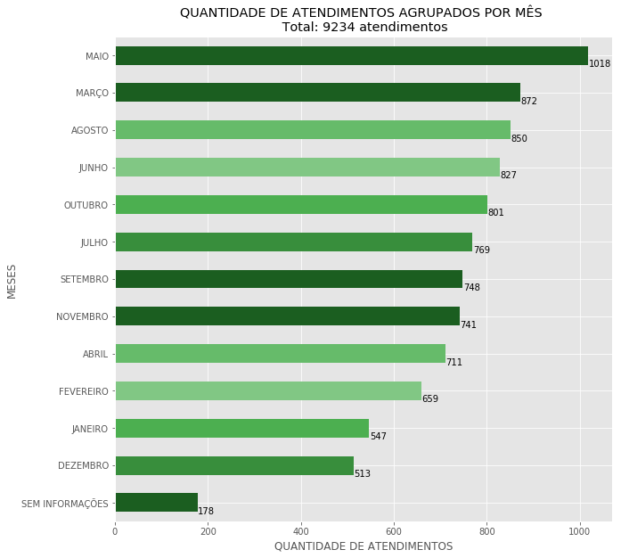

```python
meses = df_17.groupby('mes')['contagem'].sum().sort_values().plot(kind= 'barh', color = random.choice(colors), figsize=(10,10))

for p in meses.patches:
    b=p.get_bbox()
    meses.annotate("{:.0f}".format(b.x1 + b.x0), (p.get_x() + p.get_width() + 1, p.get_y() - 0.05))
plt.title('QUANTIDADE DE ATENDIMENTOS AGRUPADOS POR MÊS \n Total: ' + str(df_17['contagem'].sum()) + ' atendimentos')
plt.ylabel('MESES')
plt.xlabel('QUANTIDADE DE ATENDIMENTOS')
plt.show()
```

*Observação: Os 02 meses com maiores demandas no INSS são Maio e Março.*

<img src = './img/cat.gif'>

## Quais os meios de indicação com maior viabilidade?

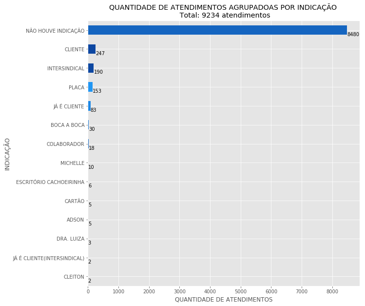

```python
indicacao = df_17.groupby('indicacao')['contagem'].sum().sort_values().plot(kind='barh', color=random.choice(colors), figsize=(10,10))
for p in indicacao.patches:
    b=p.get_bbox()
    indicacao.annotate("{:.0f}".format(b.x1 + b.x0), (p.get_x() + p.get_width() + 1, p.get_y() - 0.05))

plt.title('QUANTIDADE DE ATENDIMENTOS AGRUPADOAS POR INDICAÇÃO \n Total: ' + str(df_17['contagem'].sum()) + ' atendimentos')
plt.ylabel('INDICAÇÃO')
plt.xlabel('QUANTIDADE DE ATENDIMENTOS')
plt.show()
```

*Nota-se que os clientes são os maiores responsáveis pelas indicações mensuradas. (cliente e já é cliente). O item boca a boca trata-se de indicações feitas por vizinhos, amigos , banca de café , etc.*

## Qual o tempo médio de formatação dos procedimentos administrativos?

Infelizmente não foi possível responder esta pergunta devido a falta de informações/parâmetros estruturados para apresentar uma informação precisa.

```python
df_17['tmf'].value_counts().head()
```

```
#NUM!                4670
Sem informa????es    3021
0                      87
1                      36
2                      16
Name: tmf, dtype: int64
```

<img src = './img/sorry.gif'>

## Quais são os maiores motivos de pendência?

[figure not shown]

```python
pendencias = df_17.groupby('pendencias')['contagem'].sum().sort_values().plot(kind='barh', color=random.choice(colors), figsize=(10,10))

for p in pendencias.patches:
    b=p.get_bbox()
    pendencias.annotate("{:.0f}".format(b.x1 + b.x0), (p.get_x() + p.get_width() + 1, p.get_y() - 0.05))

plt.title('QUANTIDADE DE ATENDIMENTOS AGRUPADOS POR PENDÊNCIAS \n Total: ' + str(df_17['contagem'].sum()) + ' atendimentos')
plt.ylabel('TIPO DE PENDÊNCIAS')
plt.xlabel('QUANTIDADE DE ATENDIMENTOS')
plt.show()
```

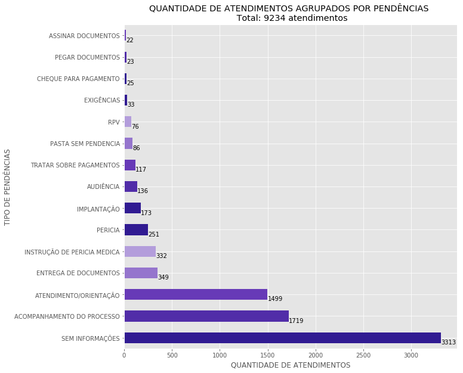

```python
pendencias = df_17.groupby('pendencias')['contagem'].sum().sort_values(ascending = False).head(15).plot(kind='barh', color=random.choice(colors), figsize=(10,10))

for p in pendencias.patches:
    b=p.get_bbox()
    pendencias.annotate("{:.0f}".format(b.x1 + b.x0), (p.get_x() + p.get_width() + 1, p.get_y() - 0.05))

plt.title('QUANTIDADE DE ATENDIMENTOS AGRUPADOS POR PENDÊNCIAS \n Total: ' + str(df_17['contagem'].sum()) + ' atendimentos')
plt.ylabel('TIPO DE PENDÊNCIAS')
plt.xlabel('QUANTIDADE DE ATENDIMENTOS')
plt.show()
```

**Ao analisar tais dados, percebi a diversificação de informações repassadas para a planilha. Tentei categorizar o maior número de informações possíveis para mensurar uma demanda para o escritório.Foram encontradas mais de 3.000 informações diferentes para pendências, ou seja, vários entendimentos para um determinado assunto.**

<img src = './img/susto.gif'>

## Ranking de atendimentos por colaboradores ?

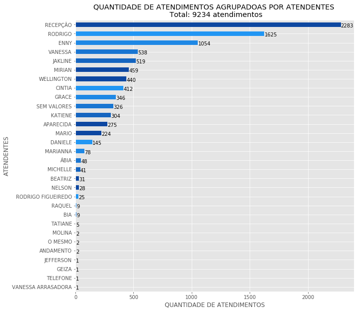

```python
rank = df_17.groupby('atendente')['contagem'].sum().sort_values().plot(kind='barh', color=random.choice(colors), figsize=(10,10))
for p in rank.patches:
    b=p.get_bbox()
    rank.annotate("{:.0f}".format(b.x1 + b.x0), (p.get_x() + p.get_width() + 1, p.get_y() - 0.05))

plt.title('QUANTIDADE DE ATENDIMENTOS AGRUPADOAS POR ATENDENTES \n Total: ' + str(df_17['contagem'].sum()) + ' atendimentos')
plt.ylabel('ATENDENTES')
plt.xlabel('QUANTIDADE DE ATENDIMENTOS')
plt.show()
```

*Existiam várias formas de preenchimento*

<img src = './img/contemple.gif'>

## Elaboração de um sistema de atendimento

- Tratar sobre a elaboração de um sistema de atendimentos.
- brainstorm.
- Quais serão as melhorias com o sistema?
- Continuidade do trabalho.